# Derivative Definition and Rules

Back to [Intro Math for Econ](https://math4econ.github.io/), [Matlab Examples](https://fanwangecon.github.io/M4Econ/), or [MEconTools](https://fanwangecon.github.io/MEconTools/) Repositories

## Linear and Non-linear Functions

Linear functions have a constant slope, but what is the rate of change for a non-linear function as we shift along its domain?

## Definition

(SB) Let $(x_0, f(x_0))$ be a point on te graph of $y=f(x)$.

The derivative of f at $x_0$ is the slope of the tangent line to the graph of f at $(x_0, f(x_0))$.

There are some common ways of denoting derivative of funtion f at $x_0$:

- $f'(x_0)$
- $\frac{df}{dx} (x_0)$
- $\frac{dy}{dx} (x_0)$
- $f_x(x_0)$

We write this analyticaly as:

$f'(x_0) = \lim_{h\rightarrow 0} \frac{f(x_0 + h) - f(x_0)}{h}$

If this limit exists, then the function f is differentiable at $x_0$.

We will use this formula to derive first order taylor approximation. And this will also appear when we derive the formula for point elasticity.

## Derivative Rules--Constant Rule

given constant k,:

- $f(x) = a\cdot x$
- $f'(x_0)=a$

```matlab
syms x a
f(x, a) = a*x
```

f(x, a) =

```matlab
dfk = diff(f,x)
```

dfk(x, a) =

a

## Derivative Rules--Power Rule (Polynomial Rule)

(SB) For any positive integer k (or real number k), the derivative of $f(x)=x^k$ at $x_0$ is:

- $f(x)=x^k$
- $f'(x_0)=k\cdot x_0^{k-1}$

```matlab
syms x a k
f(x, a, k) = a*x^k
```

f(x, a, k) =

```matlab
dfk = diff(f,x)
```

dfk(x, a, k) =

## Derivative Rules--Chain Rule

- $f(x)=p(q(x))$
- $f'(x_0)=p'(q(x_0))\cdot q'(x_0)$

```matlab
syms x a k
f(x, a, k) = (a*x)^k
```

f(x, a, k) =

```matlab
dfk = diff(f,x)
```

dfk(x, a, k) =

## Derivative Rules--Sum (and difference) Rule

Given functions p and q that are differentiable at x, then:

- $f(x) = p(x) + q(x)$
- $f'(x) = p'(x) + q'(x)$

```matlab
syms x a b c d
f(x, a, b, c, d) = a*x^b + c*x^d
```

f(x, a, b, c, d) =

```matlab
dfk = diff(f,x)
```

dfk(x, a, b, c, d) =

## Derivative Rules--Product Rule

Given functions p and q that are differentiable at x, then:

- $f(x) = p(x) \cdot q(x)$
- $f'(x) = p'(x)\cdot q(x) + p(x) \cdot q'(x)$

```matlab
syms x a b c d
f(x, a, b, c) = (a*x^b)*(c*x^d)
```

f(x, a, b, c) =

```matlab
dfk = diff(f,x)
```

dfk(x, a, b, c) =

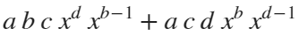

## Derivative Rules--Quotient Rule

Given functions p and q that are differentiable at x, then:

- $f(x) = \frac{p(x)}{q(x)}$
- $f'(x) = \frac{p'(x)\cdot q(x) - p(x) \cdot q'(x) }{ (q(x)) ^2 }$

Note that the quotient rule is based on the product rule, because:

- $f(x) = \frac{p(x)}{q(x)}=p(x) \cdot \frac{1}{q(x)}$

So you can derive the quotient rule formula based on the product rule where the first term is $p(x)$ and the second term is $\frac{1}{q(x)}$.

```matlab
syms x a b c d
f(x, a, b, c) = (a*x^b)/(c*x^d)
```

f(x, a, b, c) =

```matlab
dfk = diff(f,x)
```

dfk(x, a, b, c) =

## Derivative Rules--Exponential

We use exponential functions in economnics a lot:

- $f(x) = \exp(a\cdot x)$
- $f'(x) = a\cdot \exp(a \cdot x)$

```matlab
syms x a
f(x, a) = exp(a*x)
```

f(x, a) =

```matlab
dfk = diff(f,x)
```

dfk(x, a) =

This is a special case of any power function

- $f(x) = c^{a\cdot x}$
- $f'(x) = a \cdot (\log{c}) \cdot c^{a \cdot x}$

note that $log(exp(c)) = c$

```matlab
syms x a c
f(x, a, c) = c^(a*x)
```

f(x, a, c) =

```matlab
dfk = diff(f,x)
```

dfk(x, a, c) =

## Derivative Rules--Log

We use Log functions in economnics a lot:

- $f(x) = \log(a \cdot x)$
- $f'(x) = \frac{1}{x}$

```matlab
syms x a
f(x, a) = log(a*x)
```

f(x, a) =

```matlab
dfk = diff(f,x)
```

dfk(x, a) =